# SMAGL Notebook - Spring 2021

?rgb (red, blue, alpha, names=NULL, maxColorValue=1) where alpha is opacity (0=transparent, 1=opaque)

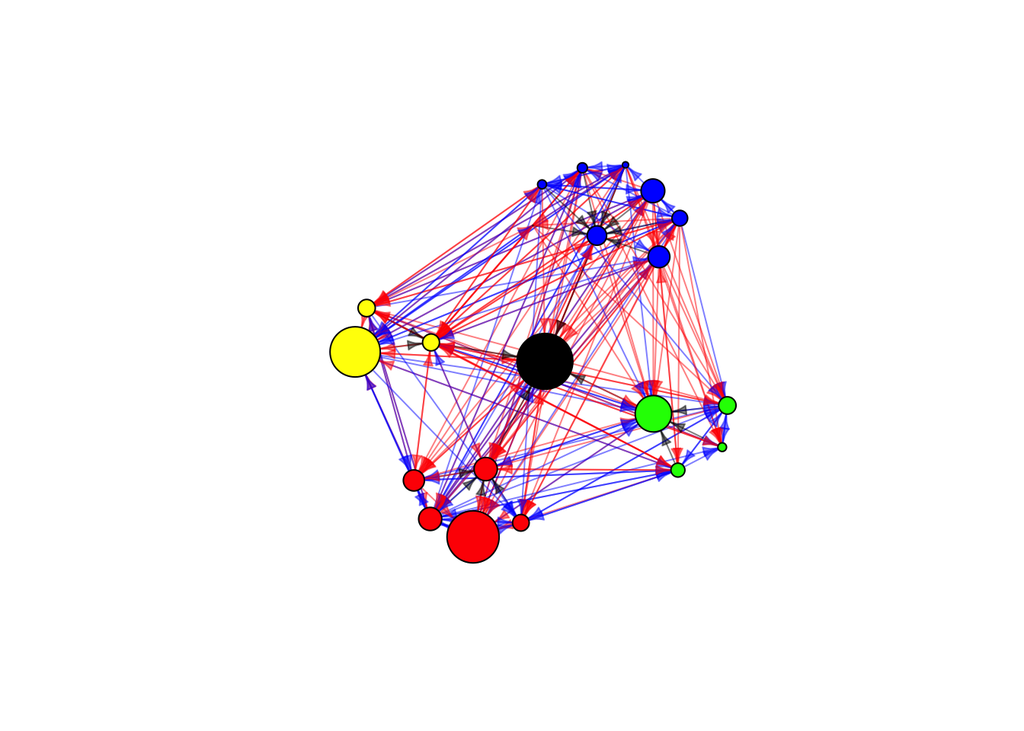

```r
tie_type_colors = c(rgb(1,0,0,.5), rgb(0,0,1,.5), rgb(0,0,0,.5)) #creates red, blue, grey(?)
E(krack_full)$color[ E(krack_full)$advice_tie==1 ] = tie_type_colors[1]
E(krack_full)$color[ E(krack_full)$friendship_tie==1 ] = tie_type_colors[2]
E(krack_full)$color[ E(krack_full)$reports_to_tie==1 ] = tie_type_colors[3]
E(krack_full)$arrow.size=.5
V(krack_full)$color = dept_vertex_colors
V(krack_full)$frame = dept_vertex_colors

plot(krack_full,
     layout=reports_to_layout,
     vertex.color=dept_vertex_colors,
     vertex.label=NA,
     edge.arrow.size=.5,
     vertex.size=tenure_vertex_sizes)
```

Lastly, I will add a legend to improve read-ability (place legend function immediately after)

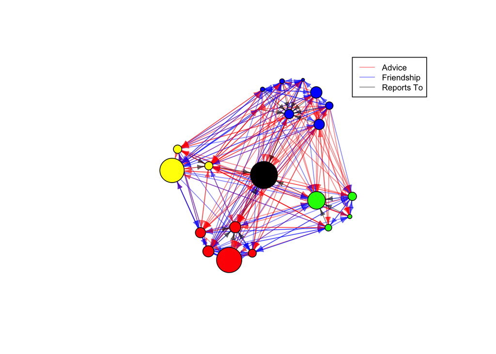

```r
plot(krack_full,
     layout=reports_to_layout,
     vertex.color=dept_vertex_colors,
     vertex.label=NA,
     edge.arrow.size=.5,
     vertex.size=tenure_vertex_sizes)
legend(1,
       1.25,
       legend = c('Advice',
                  'Friendship',
                  'Reports To'),
       col = tie_type_colors,
       lty=1,
       cex = .7)
```

## 2.2 Walk through of/Notes on: Sadler 2017

[Sadler J. (2017) Introduction to Network Analysis with R.](https://www.jessesadler.com/post/network-analysis-with-r/)

# 3 Beginning with Vervet Dataset

## 3.1 Getting started with help from Laura

[Pre-Release Social Proximity Dataset](https://raw.githubusercontent.com/nickmikulski/Spring2021/main/Pre-release_Social%20Proximity_csv.csv)

Loading necessary packages (File would not knit without putting these in a chunk)

```r
library(curl)
library(dplyr)
library(tidyverse)
```

### 3.1.1 Inputting Datasets

```r
pre_socnet<- curl("https://raw.githubusercontent.com/nickmikulski/Spring2021/main/Pre-release_Social%20Proximity_csv.csv")
pre_socnet<- read.csv(pre_socnet, header = T, na.strings=c(""," ","NA"))
#head(pre_socnet) #check the data to make sure it's uploaded correctly
#str(pre_socnet)

post_socnet<- curl("https://raw.githubusercontent.com/langley1/LWTdata2016/main/Post-release_Social%20Proximity.csv")
post_socnet<- read.csv(post_socnet, header = T, na.strings=c(""," ","NA"))
#head(post_socnet) #check the data to make sure it's uploaded correctly
```

### 3.1.2 Editting the dataframe

```r
pre_socnet_close<- pre_socnet %>% #creating a new dataframe called pre_socnet_close using data from the original pre_socnet dataframe
  filter(Focal.ID != "BT", #this code REMOVES all data that has Batman has the focal ID (BT is wild male from prerelease)
         Association != "BT", #this code REMOVES all data that has Batman in association column
         Proximity.Code %in% c("1","2") #this code only keeps proximity codes 1,2 (excluding 3,4) because we are focusing on closer proximity
  )
```

### 3.1.3 Taking out a sub-sample from dataframe

This section pulls out a few specific individuals in order to practice coding using the dataframe

```r
pre_socnet_sample<- pre_socnet_close %>%
  filter(Focal.ID %in% c("PO","BL","KO","ZI","AM"), Association %in% c("PO","BL","KO","ZI","AM"))
```

### 3.1.4 Creating a matrix of sub-sample

```r
# 1. Create a character vector of all the focal IDs in dataset:
pre_sn_sample_IDs<-as.character(unique(pre_socnet_sample$Focal.ID))
pre_sn_sample_IDs
```

```
## [1] "PO" "BL" "ZI" "AM" "KO"
```

```r
# 2. Get a list of dataframes, subsetted by monkey ID:
pre_sn_sample_monkeylist<-lapply(pre_sn_sample_IDs, function(x){pre_socnet_sample[pre_socnet_sample[["Focal.ID"]] == x, ]})
# The line above is a little bit confusing. It is creating a separate dataframe for each individual based on their focal id
#head(pre_sn_sample_monkeylist) #hidden for knitting
```

```r
# 3. Group each by focal/associate, and count how many times they are observed close together:
pre_sn_sample_grouped<-
  pre_sn_sample_monkeylist %>%
  purrr::map(~group_by(.,Association)) %>%
  purrr::map(~summarize(.,count=n()))
#pre_sn_sample_grouped
```

?purrr::map # This is pulling the map command from the purrr package  
?~ # The tilde (dependentvariable~independent)

```r
names(pre_sn_sample_grouped) <- pre_sn_sample_IDs #this gives each grouped list the name of the Focal ID
#pre_sn_sample_grouped

# 4. Set up pairwise combinations of interacting monkeys:
pre_sn_sample_monkeycombos<-list(focal=pre_sn_sample_IDs, associate=pre_sn_sample_IDs) #create list of all possible focals/associates
pre_sn_sample_filt<- function(x, y) {x == y} #create function to filter out same-monkey pairs ("PO is close to PO")
pre_sn_sample_combo<- pre_sn_sample_monkeycombos %>% cross_df(.,.filter=pre_sn_sample_filt) #get the filtered combined list as a dataframe
#head(pre_sn_sample_combo)
```

?cross_df #

```r
# 5. Create new dataframes with specific criteria
pre_sn_sample_combo2<-
  pre_sn_sample_combo %>%
  mutate(absent1 = map2_chr( #new column called "absent1"
    focal,
    associate,
    ~if_else(.x %in% names(pre_sn_sample_grouped),true="TRUE",false="FALSE"))) %>%
    mutate(absent2 = map2_chr(
    focal,
    associate,
    ~if_else(.y %in% pre_sn_sample_grouped[[.x]]$Association,true="TRUE",false="FALSE"))) %>%
  filter(absent1 == "TRUE") %>%
  filter(absent2 == "TRUE") %>%
  dplyr::select(-absent1,-absent2) #this removes those two new columns you made so you're just left with the ID names

pre_sn_sample_combo3<- pre_sn_sample_combo2 %>%
  mutate(proximity = map2_int( #new column called "proximity" that is the count for when proximity code = 1 or 2
    focal,
    associate,
    ~pre_sn_sample_grouped %>% pluck(.x) %>% filter(Association==.y) %>% as.data.frame(.) %>% .[,2]))
head(pre_sn_sample_combo3)
```

```
## # A tibble: 6 x 3
##   focal associate proximity
##   <chr> <chr>         <int>
## 1 BL    PO               82
## 2 ZI    PO               18
## 3 AM    PO               82
## 4 KO    PO               46
## 5 PO    BL              103
## 6 ZI    BL               13
```

Finally, create the matrix

```r
# 6. Create your matrix
pre_sn_sample_matrix<-spread(pre_sn_sample_combo3,associate,proximity) %>% column_to_rownames(var="focal") %>% data.matrix()
pre_sn_sample_matrix
```

```
##    AM  BL KO PO ZI
## AM NA  93 66 82 18
## BL 88  NA 64 82 10
## KO 61  67 NA 46 25
## PO 89 103 37 NA 13
## ZI 30  13 23 18 NA
```

?spread

## 3.2 Creating a social network plot based on this matrix

### 3.2.1 Converting the matrix into a data frame

?as.data.frame

?rowwise

```r
pre_sn_sample_df <- as.data.frame(pre_sn_sample_matrix, stringsAsFactors = TRUE, row.names = c("AM", "BL", "KO", "PO", "ZI"), col.names=c("AM", "BL", "KO", "PO", "ZI"))
pre_sn_sample_df
```

```
##    AM  BL KO PO ZI
## AM NA  93 66 82 18
## BL 88  NA 64 82 10
## KO 61  67 NA 46 25
## PO 89 103 37 NA 13
## ZI 30  13 23 18 NA
```

Plotting this newly formed data frame:

```r
library(igraph)

pre_sn_sample_edges <- pre_sn_sample_df #assigning the matrix data frame to our edges
pre_sn_sample_nodes <- c("AM", "BL", "KO", "PO", "ZI")
```

?graph_from_data_frame

?graph.data.frame

?as.data.frame

?subset

### 3.2.2 Plotting based on dataframe

```r
library(igraph)

pre_sn_sample_df2 <- as.data.frame(pre_sn_sample_combo3, stringsAsFactors = TRUE, row.names = c("AM", "BL", "KO", "PO", "ZI"))

pre_sn_sample_graph <- graph_from_data_frame(d=pre_sn_sample_df2, vertices = pre_sn_sample_nodes, directed = TRUE) #using the step before the matrix

pre_sn_sample_graph
```

```
## IGRAPH 34b6893 DN-- 5 20 --
## + attr: name (v/c), proximity (e/n)
## + edges from 34b6893 (vertex names):
##  [1] BL->PO ZI->PO AM->PO KO->PO PO->BL ZI->BL AM->BL KO->BL PO->ZI BL->ZI
## [11] AM->ZI KO->ZI PO->AM BL->AM ZI->AM KO->AM PO->KO BL->KO ZI->KO AM->KO
```

My original intention was to use the matrix that we just created in order to plot the social network, however, I keep getting an error message that says "Some vertex names in edge list are not listed in vertex data frame. I tried trouble shooting this with no success, so I instead tried to work with the dataframe that we created right before the matrix (pre_sn_sample_combo3), and I had some success. Below is how I was originally trying to create the graph using the matrix.

Alternatives (?):  
pre_sn_sample_graph <- graph_from_data_frame(d=pre_sn_sample_edges, vertices = pre_sn_sample_nodes, directed = TRUE) #Using the matrix

?plot

?rep

```
library(igraph)

proximityw <- as.numeric(unlist(select(pre_sn_sample_combo3, "proximity"))) #Creating a numeric vector from the proximity values in order to visualize in plot

#Trying to categorize by color
proxmax <- max(select(pre_sn_sample_combo3, "proximity"), na.rm = TRUE)
proxmin <- min(select(pre_sn_sample_combo3, "proximity"), na.rm = TRUE)
proxrange <- proxmax - proxmin
proxquarter <- proxrange/4

colorcat1 <- ((proxmin):(proxmin + (1*proxquarter)))
colorcat2 <- ((proxmin + proxquarter):(proxmin + (2*proxquarter)))
colorcat3 <- ((proxmin + (2*proxquarter)):(proxmin + (3*proxquarter)))
colorcat4 <- ((proxmin + (3*proxquarter)):proxmax)

color = c('White', 'Yellow', 'Orange', 'Red')
edgecolors <- (
  color[which(proximity$colorcat1)] = 'white',
  color[which(proximity$colorcat2)] = 'yellow',
  color[which(proximity$colorcat3)] = 'orange',
  color[which(proximity$colorcat1)] = 'red'
)

plot(pre_sn_sample_graph, vertex.size=20, edge.width=((1/25)*(proximityw)), edge.curved=TRUE, edge.color=edgecolors)
```

rlang::last_error()

?E

# 4 Citations

## 4.1 R Coding References

- [Barbera P. (2017) Introduction to social network analysis with R.](http://pablobarbera.com/big-data-upf/html/02a-networks-intro-visualization.html)
- [McFarland DA, Messing S, Nowak M, Westwood SJ. (2010) Network Analysis Labs in R and SoNIA.](https://sna.stanford.edu/rlabs.php)
- [Sadler J. (2017) Introduction to Network Analysis with R.](https://www.jessesadler.com/post/network-analysis-with-r/)
- [Zhang G. (2010) Social network analysis with R sna package.](https://www.r-project.org/nosvn/conferences/useR-2010/slides/Zhang.pdf)

## 4.2 Social Network Analysis Literature

- [Brent LJN, Lehmann J, Ramos-Fernández G. (2011) Social network analysis in the study of nonhuman primates: A historical perspective. *American Journal of Primatology*, **73**, 720-730.](https://doi.org/10.1002/ajp.20949)
- [Guy AJ, Stone OML, Curnoe D. (2012) The release of a troop of rehabilitated vervet monkeys (Chlorocebus aethiops) in KwaZulu-Natal, South Africa: Outcomes and Assessment. *Folia Primatologica*, **82**, 308-320.](https://doi.org/10.1159/000337269)
- [McCowan B, Anderson K, Heagarty A, Cameron A. (2008) Utility of social network analysis for primate behavioral management and well-being. *Applied Animal Behaviour Science*, **109**, 396-405.](https://doi.org/10.1016/j.applanim.2007.02.009)
- [Puga-Gonzalez I, Sosa S, Sueur C. (2019) Editorial: Social networks analyses in primates, a multilevel perspective. *Primates*, **60**, 163-165.](https://doi.org/10.1007/s10329-019-00720-5)
- [Sueur C, Jacobs A, Amblard F, Petit O, King AJ. (2011) How can social network analysis improve the study of primate behavior? *American Journal of Primatology*, **73**, 703-719.](https://doi.org/10.1002/ajp.20915)